# Econometría II

v. 2024.12.18

PDF

## Ejemplo con una distribución Bernoulli

## Ejemplo con una distribución Bernoulli (1/5)

Supongamos que existen dos ruletas como sigue:

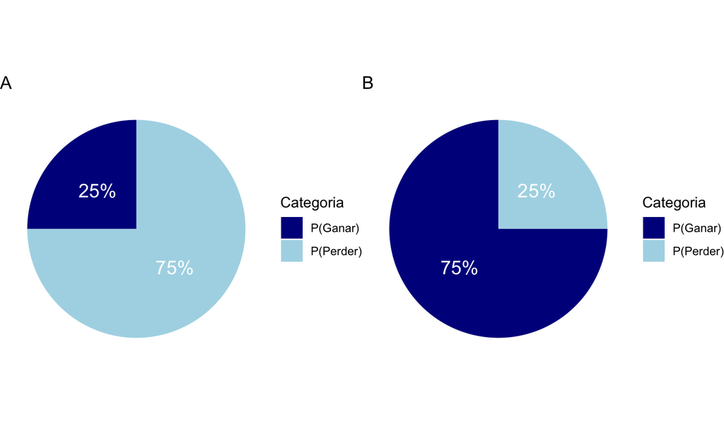

Despues de girar una ruleta tres veces obtienes la secuencia: Gana-Gana-Pierde. ¿Puedes adivinar que ruleta giraste?

## Ejemplo con una distribución Bernoulli (2/5)

Sea \(p\) la probabilidad de ganar. Para el ejemplo anterior tenemos:

\[ p=\begin{cases} 0.25 \;\text{si ruleta A}\\[5pt] 0.75\; \text{si ruleta B} \end{cases} \]

Entonces, la probabilidad de obtener la combinación Gana-Gana-Pierde es:

\[ p_{Gana-Gana-Pierde}=\begin{cases} 0.0469 \; \text{si ruleta A}\\[5pt] 0.1406 \; \text{si ruleta B} \end{cases} \]

## Ejemplo con una distribución Bernoulli (3/5)

Concluimos que es más probable que hayas girado la ruleta B y que el mejor estimador de \(p\) para la combinación Gana-Gana-Pierde es:

\[ \hat{p}=0.75 \]

Este es el **estimador de máxima verosimilitud** para este ejemplo.

## Ejemplo con una distribución Bernoulli (4/5)

Ahora supongamos que \(p\) puede tomar cualquier valor (entre cero y uno). Si observaste la secuencia Gana-Gana-Pierde, ¿Cuál es el valor de \(p\) más probable? Nota que la probabilidad de obtener esta secuencia se calcula como:

\[ L(p)=p\times p \times(1-p)=p^2-p^3 \]

La función \(L(p)\) es la función de verosimilitud para este ejemplo. Esta depende del valor desconocido, \(p\).

## Ejemplo con una distribución Bernoulli (4/4)

Deducimos que el valor de \(p\) más probable es aquel que maximiza la función de verosimilitud:

\[ p=\text{arg} \max_p\;L(p) \]

Entonces es fácil encontrar que:

\[ \hat{p}=\frac{2}{3} \]

## Ejemplo con una distribución normal

## Distribución normal, 2 observaciónes (1/5)

Ahora supongamos que dos observaciones independientes, \(x_1=4\) y \(x_2=6\), provienen de una distribución normal con media \(\mu\) y varianza \(\sigma^2\). Recordemos que la función de densidad de una normal es:

\[ f(x)=\frac{1}{\sigma\sqrt{2\pi}}e^{-\frac{1}{2}\left(\frac{x-\mu}{\sigma}\right)^2} \]

Como en el ejemplo anterior, primero supongamos que \(\mu=3.5\) y \(\sigma^2=1\). ¿Cuál es la probabilidad de observar los valores \(x_1=4\) y \(x_2=6\)?

## Distribución normal, 2 observaciones (2/5)

Ejercicio

Muestra que si \(\mu=3.5\) y \(\sigma^2=1\) la probabilidad de obtener \(x_1=4\) y \(x_2=6\) es:

\[ f_{x_2,x_2}(x_1=4, x_2=6)=0.0062 \]

Muestra, además, que si \(\mu=4\) y \(\sigma^2=1\):

\[ f_{x_2,x_2}(x_1=4, x_2=6)=0.0215 \]

## Distribución normal, 2 observaciones (3/5)

Supongamos ahora que \(\sigma^2=1\), pero que \(\mu\) puede tomar cualquier valor. En este caso, la función de verosimilitud sería:

\[ L(\mu)=f(x_1)f(x_2)=\left[\frac{1}{\sigma\sqrt{2\pi}}e^{-\frac{1}{2}(4-\mu)^2}\right]\left[\frac{1}{\sigma\sqrt{2\pi}}e^{-\frac{1}{2}(6-\mu)^2}\right] \]

El procedimiento es el mismo de antes, aunque la función es un poco más complicada de derivar.

## Distribución normal, 2 observaciones (4/5)

Esta se conoce como **función de log-verosimilitud**.

## Distribución normal, 2 observaciones (5/5)

Ejercicio

Muestra que el estimador de máxima verosimilitud en nuestro ejemplo es:

\[ \hat{\mu}=5 \]

## Distribución normal, \(n\) observaciones (1/3)

¿Que pasa si tenemos \(n\) observaciones (y \(\sigma^2=1\))? En este caso, la función de verosimilitud es:

\[ L(\mu)=\prod_{i=1}^{n}f(x_i)=\prod_{i=1}^{n}\frac{1}{\sqrt{2\pi}}e^{-\frac{1}{2}(x_i-\mu)^2} \]

## Distribución normal, \(n\) observaciones (2/3)

Ejercicio

Calcula la función de log-verosimilitud cuando \(n\) datos independientes provienen de una distribución normal con \(\sigma^2=1\). Calcula luego el estimador de máxima verosimilitud de \(\mu\).

Comenta.

## Distribución normal, \(n\) observaciones (3/3)

Ejercicio

Calcula la función de verosimilitud y log-verosimilitud para \(n\) datos independientes que provienen de una distribución normal con parametros \(\mu\) y \(\sigma^2\) desconocidos. Calcula los estimadores de máxima verosimilitud.

## Aplicación: el modelo de regresión simple

## Estimación del modelo de regresión simple por MV (1/3)

Considera el siguiente modelo de regresión simple:

\[ \begin{align} y_i&=\beta_1+\beta_2x_i+u_i\\[5pt] u_i&\:\sim\: \mathcal{N}(0, \sigma^2) \end{align} \]

con \(i=1,\ldots,n\). Nota que la función de densidad del término de error, \(u\), es:

\[ \begin{align} f(u)=&\frac{1}{\sigma\sqrt{2\pi}}e^{-\frac{1}{2}\left(\frac{u}{\sigma}\right)^2}\\[5pt] =& \frac{1}{\sigma\sqrt{2\pi}}e ^{-\frac{1}{2}\left(\frac{y-\beta_1-\beta_2x}{\sigma}\right)^2} \end{align} \]

## Estimación del modelo de regresión simple por MV (2/3)

Dado que tenemos \(n\) observaciones, la función de verosimilitud para \(\beta_1,\: \beta_2\) y \(\sigma\) desconocidos es:

\[ \begin{align} L(\beta_1,\beta_2,\sigma)&=\prod_{i=1}^{n}f(u_i)\\[8pt] &=\prod_{i=1}^{n}\frac{1}{\sigma\sqrt{2\pi}}e^{-\frac{1}{2}\left(\frac{y_i-\beta_1-\beta_2x_i}{\sigma}\right)^2} \end{align} \]

## Estimación del modelo de regresión simple por MV (3/3)

Ejercicio

Calcula la función de log-verosimilitud para el modelo de regresión simple. Calcula luego los estimadores de máxima verosimilitud de \(\beta_1,\:\beta_2\) y \(\sigma\). Comenta.